# **Assignment_2_MSB1015**

Wiep Stikvoort

October 13, 2019

# **Creating a Partial Least Squares (PLS) regression model for the prediction of boiling points**

#### i6092796

#### MSB1015 Scientific Programming

When there is a reference to README.md file in the repository, you can find the information via: https://github.com/wiepstikvoort/MSB1015_Assignment2/blob/master/README.md  
Firstly, the libraries needed for the loading of the data, and for the computations to create the regression model need to be installed and loaded.

## **Alkanes and their boiling points**

### **Loading and processing of the data**

The data can now be loaded from WikiData using SPARQL. The query retrieves alkanes that have a boiling point in wikidata (please see the README.md file in the repository for more information on the query).

However, not all boiling points are in the same unit. After converting the boiling points that are in Fahrenheit or Celsius to Kelvin, the data can be checked. To check whether there are no more strange values, such as divergent units, in the dataset, a plot is created. This plot should show that all points are somewhat in the same range of values.

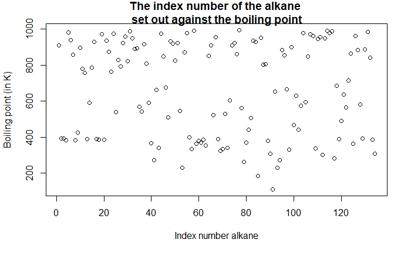

As can be seen in the graph above there is a nice distribution of boiling points. There do not seem to be any divergent values in the data.

### **SMILES and descriptors**

The data is split into test and training set. 80% of the data is used for the training set, the other 20% will then logically be part of the test set.

Chemical properties, descriptors, of the alkanes are needed to base the PLS model on. The SMILES (Simplified Molecular-Input Line-Entry System) of the alkanes were needed to find and calculate the descriptors. The classes used for these descriptors are discussed in the README.md file in the repository.

### **Creating the PLS model**

The descriptors and processed data are now within a data frame, from which can be worked to create the prediction model. The function plsr (from the pls package) was used to create the model. The model can be visualized in a graph, as shown below. The x axis depicts the measured data, so the true boiling points, and the y axis depicts the predicted boiling points based on the model. The model needs to be accurate, yet as simple as possible. The number of components can play a role here. To see how many components the model needs, a graph where the number of components are set out against the Root Mean Square Error of Prediction (RMSEP), as well as the number of components set out against R^2, can help.

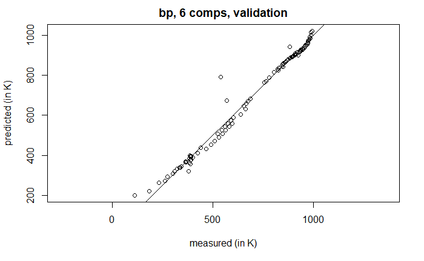

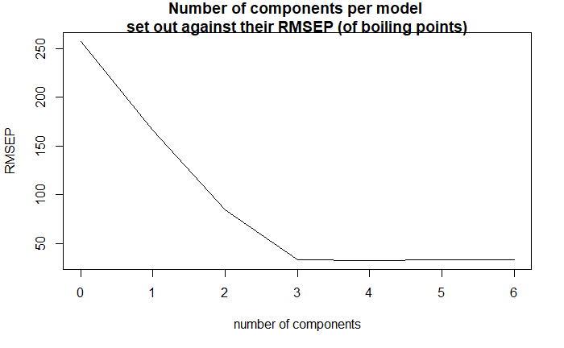

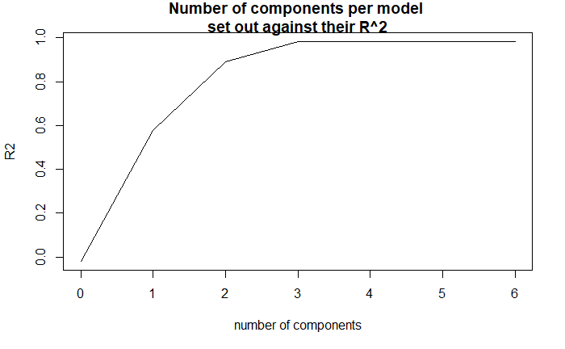

The RMSEP and R^2 graphs both show that 3 components yields a model that would not improve anymore by adding more components. The RMSEP does not decline anymore, and the R^2 does not increase anymore. Therefore a model with 3 components is chosen to work with.

### **Testing the PLS model**

The input for the PLS model needs to have the same descriptors as were used in the creation of the model. Therefore, the descriptors, based on the SMILES, were retrieved for the test set as well. This was used as input for the testing of the model. The model uses the descriptors to predict the boiling points of the alkanes.  
The table shows the RMSEP per number of components. The graph below shows the same values. Just as the training set, the test set shows that 3 components is the optimal number for this model, based on accuracy and simplicity.

```
(Intercept)      1 comps      2 comps      3 comps      4 comps      5 comps      6 comps
     265.71       161.42        81.54        35.27        45.54        44.37        44.37
```

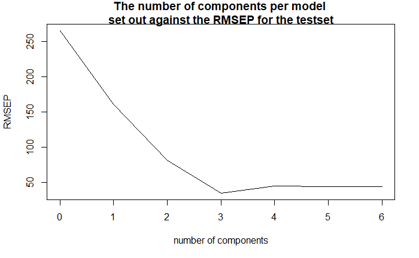

To predict the boiling points based on the descriptors, the function predict() is used. The values retrieved from the prediction were set out against the true data, and shown in the graph below. The points are in an approximately straight line, meaning that the predicted values and true values are very close together, and that their are no biases as to where the boiling points are predicted best (low or high boiling points).

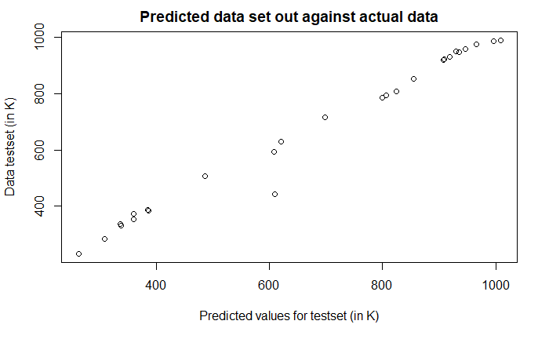

The correlation coefficient between the true boiling points and the predicted boiling points (for this specific training and test set) is:

```
[1] 0.9916406
```

# ________________________________________________

## **Amino acids and their masses**

### **Loading and processing of the data**

To check the reproducibility of the code, another model was created by almost copying the code for the PLS model that predicts the alkane boiling points (further explanation is given in the README.md file in the repository). All graphs and tables were reproduced, based on the same theory and same function, but different data. All graphs below were based on the amino acid data.

The amino acids (aa) and their masses were loaded from WikiData using SPARQL. All compound masses were expressed in the atomic mass unit (which is equivalent to g/mol), so no need for conversions.

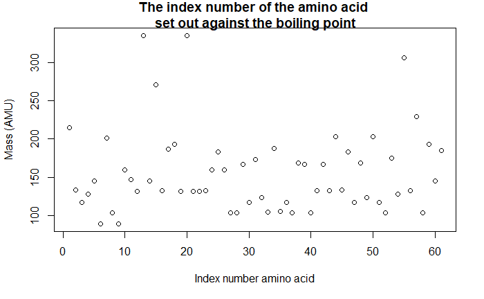

The graph seemed to show some outliers. However, after a small literature research, these amino acids turned out to simply be a little heavier than most other amino acids.

### **SMILES and descriptors**

The same methods were implemented as were described and used for the creation of the alkane boiling points PLS model, unless otherwise specified. The one main thing that was changed were the variable names to prevent confusion.

### **Creating the PLS model**

The model is visualized in the same manner as is shown for the alkane model:

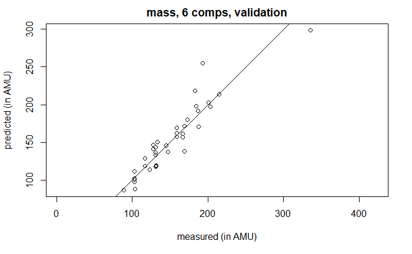

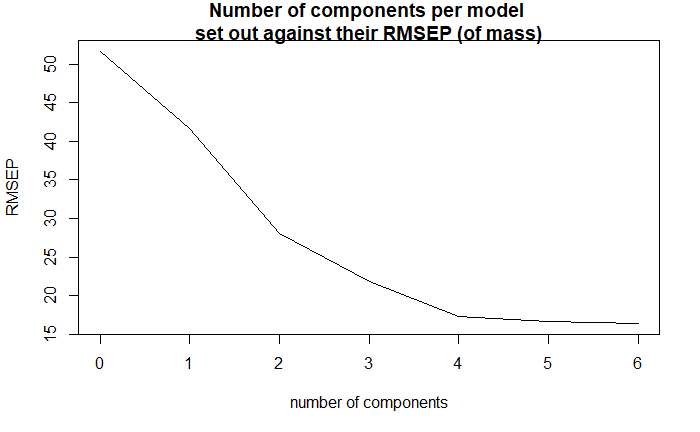

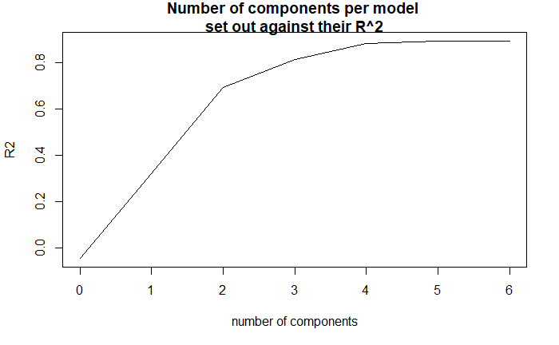

### **Testing the PLS model**

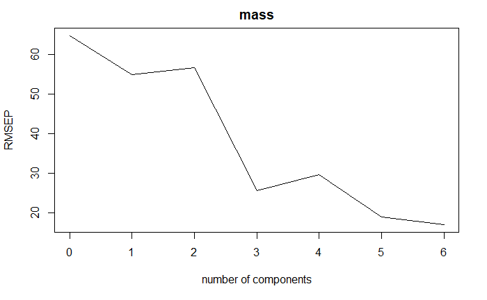

```
(Intercept)      1 comps      2 comps      3 comps      4 comps      5 comps      6 comps
      64.87        55.00        56.80        25.70        29.68        19.06        17.15
```

The graph showing the predicted masses and the true masses of the amino acids, shown below, shows a linear behavior. The points do not allign as neatly as they did for the alkane boiling points model however. This can be due to the fact that the dataset is smaller, or because there are better descriptors to be used to create this PLS model.

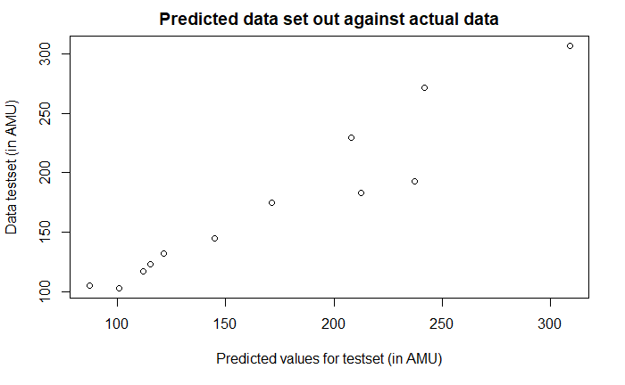

The correlation coefficient between the true masses and the predicted masses (for this specific training and test set) is:

```
[1] 0.955797
```

# ________________________________________________

### **Conclusion**

Using SPARQL and R a PLS model can be created to predict the boiling points of alkanes. The code was easily reused. A different dataset with boiling points would have been a better fit for this assignment, to be able to compare the models better. However, to find out whether a different dataset could be implemented easily, this was not necessary. The correlation coefficients and the values (and thus the graphs) for the RMSEP can change when the script is rerun. This depends on which compounds are randomly distributed over the training and test sets. If most compounds with low boiling points are in the training set, and all compounds with high boiling points in the test set for example, the model has trouble predicting with the same accuracy as when the boiling points are evenly distributed over training and test set.